# HW1_Distro

Christopher Bloome

3/2/2021

–

# Libraries

```r
library(knitr)
library(tidyverse)
library(reshape2)
library(VIM)
library(corrplot)
library(naniar)
library(ggplot2)
```

# Data

In this homework assignment, we are asked to explore, analyze and model a baseball data set containing approximately 2200 records. Each record represents a professional baseball team from the years 1871 to 2006 inclusive. Each record has the performance of the team for the given year, with all of the statistics adjusted to match the performance of a 162 game season.

# Load Data

```r
#train <- read.csv('./moneyball-training-data.csv')
#test <- read.csv('./moneyball-evaluation-data.csv')

train <-read.csv("https://raw.githubusercontent.com/ChristopherBloome/621/main/moneyball-training-data.csv")
test <- read.csv("https://raw.githubusercontent.com/ChristopherBloome/621/main/moneyball-evaluation-data.csv")

#Removing the index variable
train$INDEX <- NULL
test$INDEX <- NULL
```

```r
head(train)
```

```
##   TARGET_WINS TEAM_BATTING_H TEAM_BATTING_2B TEAM_BATTING_3B TEAM_BATTING_HR
## 1          39           1445             194              39              13
## 2          70           1339             219              22             190
## 3          86           1377             232              35             137
## 4          70           1387             209              38              96
## 5          82           1297             186              27             102
## 6          75           1279             200              36              92
##   TEAM_BATTING_BB TEAM_BATTING_SO TEAM_BASERUN_SB TEAM_BASERUN_CS
## 1             143             842              NA              NA
## 2             685            1075              37              28
## 3             602             917              46              27
## 4             451             922              43              30
## 5             472             920              49              39
## 6             443             973             107              59
##   TEAM_BATTING_HBP TEAM_PITCHING_H TEAM_PITCHING_HR TEAM_PITCHING_BB
## 1               NA            9364               84              927
## 2               NA            1347              191              689
## 3               NA            1377              137              602
## 4               NA            1396               97              454
## 5               NA            1297              102              472
## 6               NA            1279               92              443
##   TEAM_PITCHING_SO TEAM_FIELDING_E TEAM_FIELDING_DP
## 1             5456            1011               NA
## 2             1082             193              155
## 3              917             175              153
## 4              928             164              156
## 5              920             138              168
## 6              973             123              149
```

```r
str(train)
```

```
## 'data.frame':    2276 obs. of  16 variables:
##  $ TARGET_WINS     : int  39 70 86 70 82 75 80 85 86 76 ...
##  $ TEAM_BATTING_H  : int  1445 1339 1377 1387 1297 1279 1244 1273 1391 1271 ...
##  $ TEAM_BATTING_2B : int  194 219 232 209 186 200 179 171 197 213 ...
##  $ TEAM_BATTING_3B : int  39 22 35 38 27 36 54 37 40 18 ...
##  $ TEAM_BATTING_HR : int  13 190 137 96 102 92 122 115 114 96 ...
##  $ TEAM_BATTING_BB : int  143 685 602 451 472 443 525 456 447 441 ...
##  $ TEAM_BATTING_SO : int  842 1075 917 922 920 973 1062 1027 922 827 ...
##  $ TEAM_BASERUN_SB : int  NA 37 46 43 49 107 80 40 69 72 ...
##  $ TEAM_BASERUN_CS : int  NA 28 27 30 39 59 54 36 27 34 ...
##  $ TEAM_BATTING_HBP: int  NA NA NA NA NA NA NA NA NA NA ...
##  $ TEAM_PITCHING_H : int  9364 1347 1377 1396 1297 1279 1244 1281 1391 1271 ...
##  $ TEAM_PITCHING_HR: int  84 191 137 97 102 92 122 116 114 96 ...
##  $ TEAM_PITCHING_BB: int  927 689 602 454 472 443 525 459 447 441 ...
##  $ TEAM_PITCHING_SO: int  5456 1082 917 928 920 973 1062 1033 922 827 ...
##  $ TEAM_FIELDING_E : int  1011 193 175 164 138 123 136 112 127 131 ...
##  $ TEAM_FIELDING_DP: int  NA 155 153 156 168 149 186 136 169 159 ...
```

All the variables are integer and TEAM_BATTING_HBP has a lot of missing values. Let’s look at the summary of the data.

```r
summary(train)
```

```
##   TARGET_WINS     TEAM_BATTING_H TEAM_BATTING_2B TEAM_BATTING_3B
##  Min.   :  0.00   Min.   : 891   Min.   : 69.0   Min.   :  0.00
##  1st Qu.: 71.00   1st Qu.:1383   1st Qu.:208.0   1st Qu.: 34.00
##  Median : 82.00   Median :1454   Median :238.0   Median : 47.00
##  Mean   : 80.79   Mean   :1469   Mean   :241.2   Mean   : 55.25
##  3rd Qu.: 92.00   3rd Qu.:1537   3rd Qu.:273.0   3rd Qu.: 72.00
##  Max.   :146.00   Max.   :2554   Max.   :458.0   Max.   :223.00
##
##  TEAM_BATTING_HR  TEAM_BATTING_BB TEAM_BATTING_SO  TEAM_BASERUN_SB
##  Min.   :  0.00   Min.   :  0.0   Min.   :   0.0   Min.   :  0.0
##  1st Qu.: 42.00   1st Qu.:451.0   1st Qu.: 548.0   1st Qu.: 66.0
##  Median :102.00   Median :512.0   Median : 750.0   Median :101.0
##  Mean   : 99.61   Mean   :501.6   Mean   : 735.6   Mean   :124.8
##  3rd Qu.:147.00   3rd Qu.:580.0   3rd Qu.: 930.0   3rd Qu.:156.0
##  Max.   :264.00   Max.   :878.0   Max.   :1399.0   Max.   :697.0
##                                   NA's   :102      NA's   :131
##  TEAM_BASERUN_CS TEAM_BATTING_HBP TEAM_PITCHING_H TEAM_PITCHING_HR
##  Min.   :  0.0   Min.   :29.00    Min.   : 1137   Min.   :  0.0
##  1st Qu.: 38.0   1st Qu.:50.50    1st Qu.: 1419   1st Qu.: 50.0
##  Median : 49.0   Median :58.00    Median : 1518   Median :107.0
##  Mean   : 52.8   Mean   :59.36    Mean   : 1779   Mean   :105.7
##  3rd Qu.: 62.0   3rd Qu.:67.00    3rd Qu.: 1682   3rd Qu.:150.0
##  Max.   :201.0   Max.   :95.00    Max.   :30132   Max.   :343.0
##  NA's   :772     NA's   :2085
##  TEAM_PITCHING_BB TEAM_PITCHING_SO  TEAM_FIELDING_E  TEAM_FIELDING_DP
##  Min.   :   0.0   Min.   :    0.0   Min.   :  65.0   Min.   : 52.0
##  1st Qu.: 476.0   1st Qu.:  615.0   1st Qu.: 127.0   1st Qu.:131.0
##  Median : 536.5   Median :  813.5   Median : 159.0   Median :149.0
##  Mean   : 553.0   Mean   :  817.7   Mean   : 246.5   Mean   :146.4
##  3rd Qu.: 611.0   3rd Qu.:  968.0   3rd Qu.: 249.2   3rd Qu.:164.0
##  Max.   :3645.0   Max.   :19278.0   Max.   :1898.0   Max.   :228.0
##                   NA's   :102                        NA's   :286
```

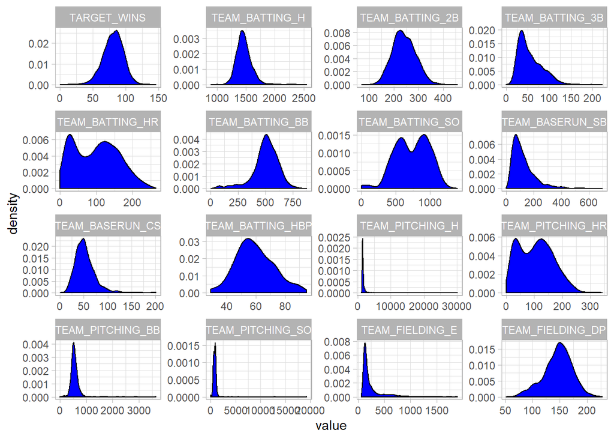

```r
g = melt(train)
ggplot(g, aes(x= value)) +
   geom_density(fill='blue') +
   facet_wrap(~variable, scales = 'free') +
   theme_light()
```

Check for rows with missing values

```r
sum(complete.cases(train))
```

```
## [1] 191
```

Check how many rows with missing values in terms of percentage

```r
sum(complete.cases(train))/(nrow(train)) *100
```

```
## [1] 8.391916
```

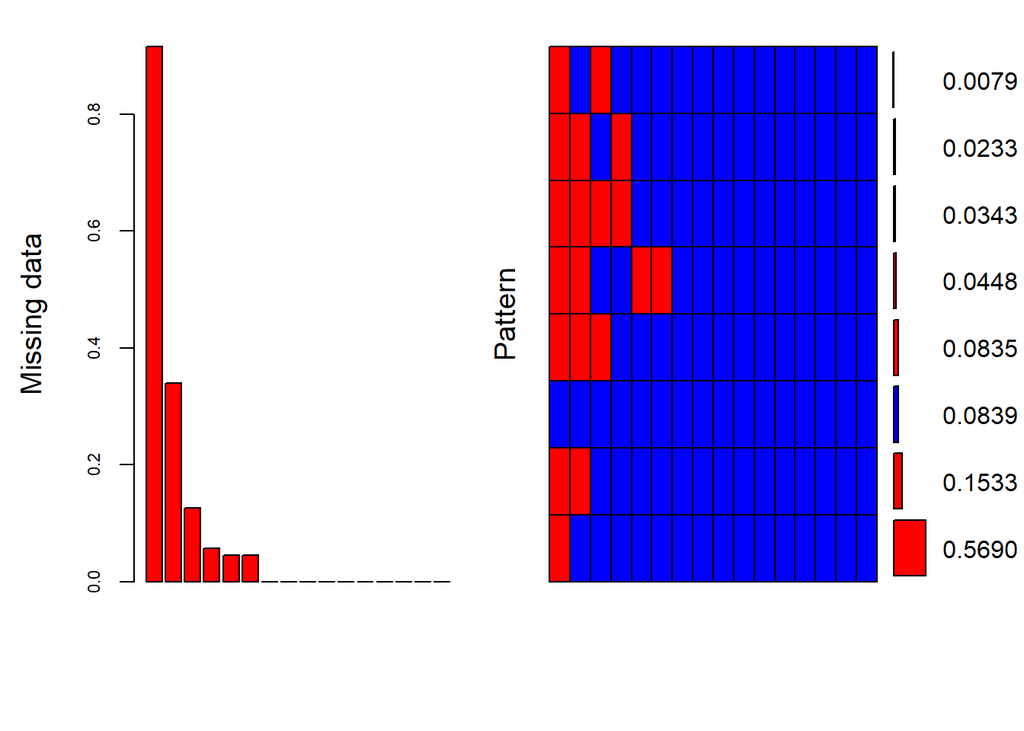

```
##
##  Variables sorted by number of missings:
##          Variable      Count
##  TEAM_BATTING_HBP 0.91608084
##   TEAM_BASERUN_CS 0.33919156
##  TEAM_FIELDING_DP 0.12565905
##   TEAM_BASERUN_SB 0.05755712
##   TEAM_BATTING_SO 0.04481547
##  TEAM_PITCHING_SO 0.04481547
##       TARGET_WINS 0.00000000
##    TEAM_BATTING_H 0.00000000
##   TEAM_BATTING_2B 0.00000000
##   TEAM_BATTING_3B 0.00000000
##   TEAM_BATTING_HR 0.00000000
##   TEAM_BATTING_BB 0.00000000
##   TEAM_PITCHING_H 0.00000000
##  TEAM_PITCHING_HR 0.00000000
##  TEAM_PITCHING_BB 0.00000000
##   TEAM_FIELDING_E 0.00000000
```

```r
missing_plot <- aggr(train, col=c('blue','red'),numbers=TRUE, sortVars=TRUE,labels=names(train), cex.axis=.7,gap=3, ylab=c("Missing data","Pattern"))
```

Six of the variable has missing values.

# Outliers

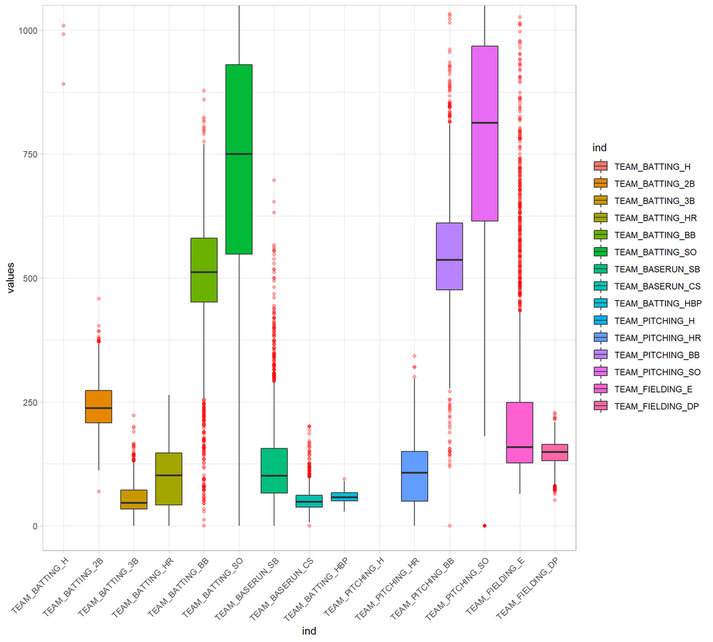

```r
ggplot(stack(train[,-1]), aes(x = ind, y = values, fill=ind)) +
  geom_boxplot(outlier.colour = "red",  outlier.alpha=.3) +
  coord_cartesian(ylim = c(0, 1000)) +
  theme_light()+
  theme(axis.text.x=element_text(angle=45, hjust=1))
```

# Correlations

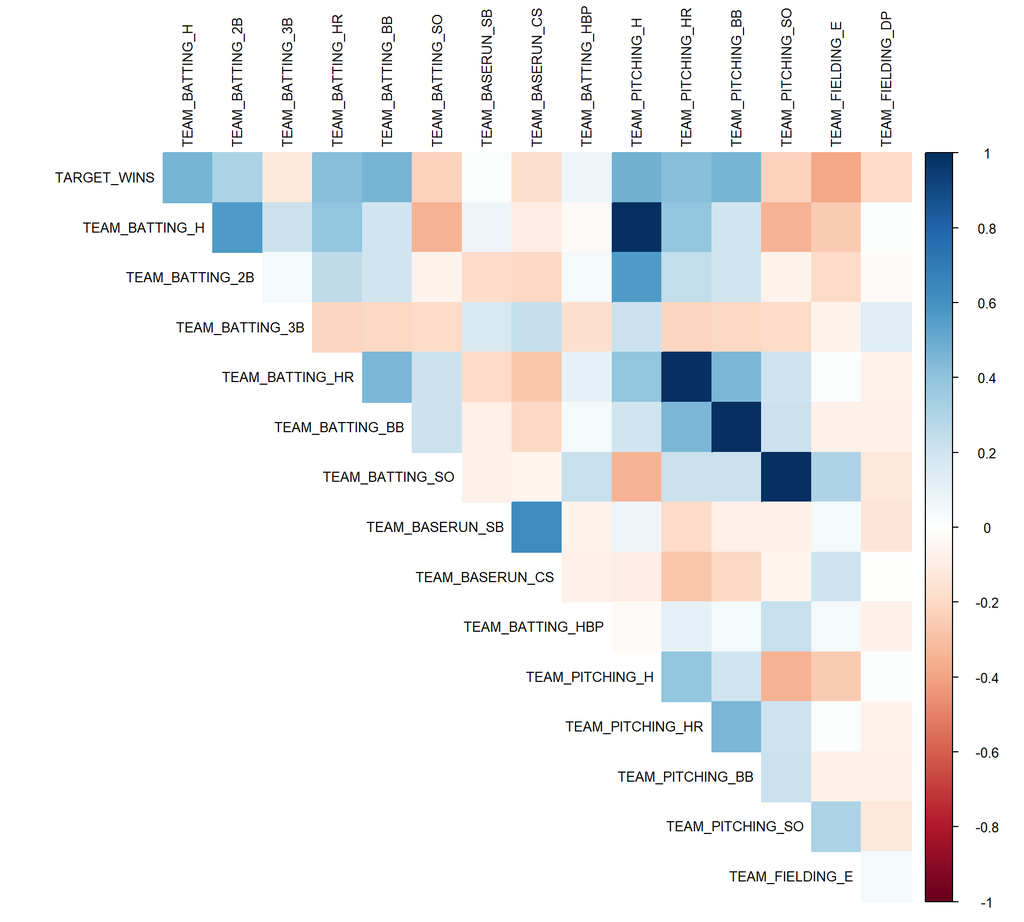

```r
train %>%
  cor(., use = "complete.obs") %>%
  corrplot(., method = "color", type = "upper", tl.col = "black", tl.cex=.8, diag = FALSE)
```

# Data Preparation

Let’s remove TEAM_BATTING_HBP as it has 91.6% missing values

```r
train <- train[-10]
```

We will investigate missing data using naniar package in order to see if we should remove missing data.

https://www.rdocumentation.org/packages/naniar/versions/0.6.0

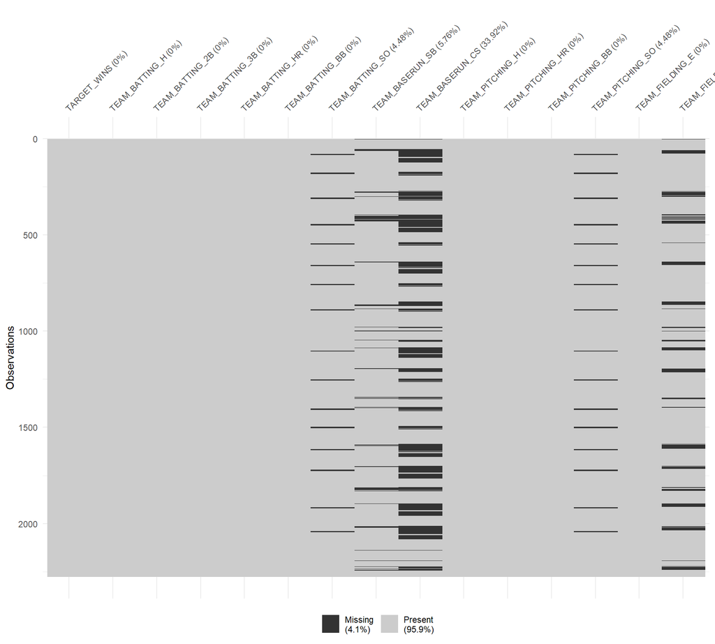

```r
vis_miss(train)
```

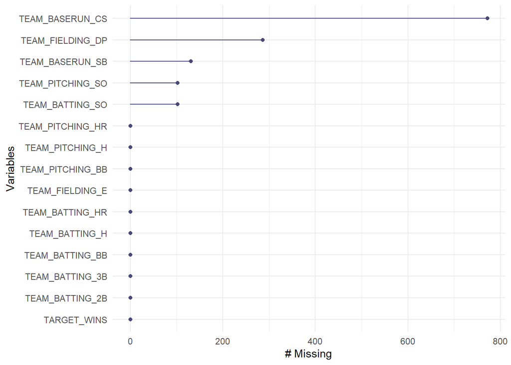

```r
gg_miss_var(train)
```

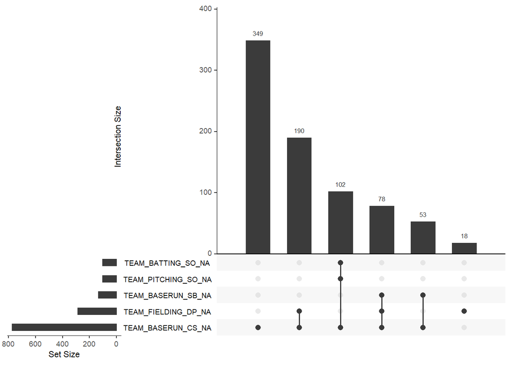

```r
par(mfrow=c(1,2))
gg_miss_upset(train,
              nsets = 5,
              nintersects = NA)
```

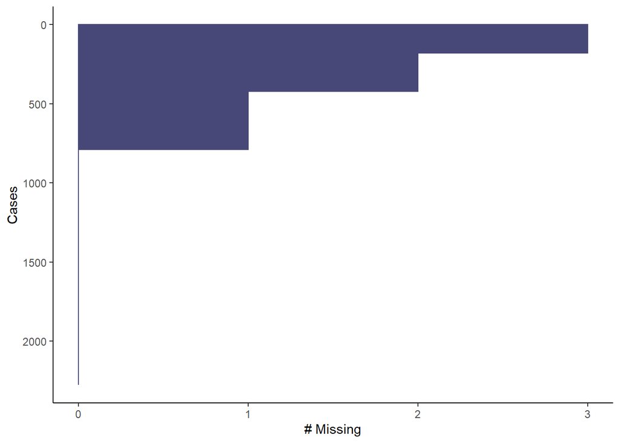

```r
gg_miss_case(train)+
  theme_classic()
```

Let’s replace extreme outliers with median

```r
train1 <- train %>% mutate(TEAM_PITCHING_H = ifelse(TEAM_PITCHING_H > 5000, median(TEAM_PITCHING_H), TEAM_PITCHING_H),
                            TEAM_PITCHING_SO = ifelse(TEAM_PITCHING_SO > 1500, median(TEAM_PITCHING_SO), TEAM_PITCHING_SO))
test1 <- test %>% mutate(TEAM_PITCHING_H = ifelse(TEAM_PITCHING_H > 5000, median(TEAM_PITCHING_H), TEAM_PITCHING_H),
                            TEAM_PITCHING_SO = ifelse(TEAM_PITCHING_SO > 1500, median(TEAM_PITCHING_SO), TEAM_PITCHING_SO))
```

Replace missing values with median

```r
train1[] <- lapply(train1, function(x) ifelse(is.na(x), median(x, na.rm=TRUE), x))
test1[] <- lapply(test1, function(x) ifelse(is.na(x), median(x, na.rm=TRUE), x))
```

```r
# Check missing values
nrow(is.na(train1))
```

```
## [1] 2276
```

```r
nrow(is.na(test1))
```

```
## [1] 259
```

# Note to teammate compiling: Above work was Forhad’s - My work below:

```r
#my packages, so they dont get lost

library(ggplot2)
library(gridExtra)
#moving the data to a new varaible, in case others are using train1

train2 <- train1
```

# Calculated Fields:

Now that we have the data reasonably clean, we can calculate some additional fields that may be of use in our models.

## SLG 1

There exists a metric called “Slugging percentage” used by baseball teams in the modern era, that effectively determines the effectiveness of a hitter. This is traditionally calculated as follows: [Singles + Doubles x 2 + Triples x 3 + HRs x 4]/[Plate Appearances].

As we do not have Plate Appearances, lets use hits in its place, effectively calculating how many bases a team gets on average each time one of its players gets a hit.

```r
train2$SLG1 <- (train2$TEAM_BATTING_H + train2$TEAM_BATTING_2B + 2*train2$TEAM_BATTING_3B + 3*train2$TEAM_BATTING_HR)/train2$TEAM_BATTING_H
```

## SLG 2

While the above demonstrates the effectiveness of a team at the plate, each of the other statistics are aggregate sums. In that spirit, lets calculate a “slugging total” that is not scaled to the number of hits.

```r
train2$SLG2 <- (train2$TEAM_BATTING_H + train2$TEAM_BATTING_2B + 2*train2$TEAM_BATTING_3B + 3*train2$TEAM_BATTING_HR)
```

## Diffs

Due to the changes in the way baseball has been played since its inception, aggregate totals may be less predictive them ratios of a team’s outcomes vs their opponents. Lets create 3 variables, that measure ratios in this way.

As we will be building a learning model, we would not want to generate differences by way of subtracting, as they would be deemed redundant later on.

```r
train2$HitDiff <- train2$TEAM_BATTING_H/ train2$TEAM_PITCHING_H

train2$WalkDiff <- train2$TEAM_BATTING_BB/ train2$TEAM_PITCHING_BB

train2$HRDiff <- train2$TEAM_BATTING_HR/train2$TEAM_PITCHING_HR

# Change NAs to Median - While NAs are caused by a value of 0 - cases where the denominator are 0 are more likely due to missing data than truly having no Hits, Walks or HRs in a season.

train2[] <- lapply(train2, function(x) ifelse(is.na(x), median(x, na.rm=TRUE), x))

summary(train2)
```

```
##   TARGET_WINS     TEAM_BATTING_H TEAM_BATTING_2B TEAM_BATTING_3B
##  Min.   :  0.00   Min.   : 891   Min.   : 69.0   Min.   :  0.00
##  1st Qu.: 71.00   1st Qu.:1383   1st Qu.:208.0   1st Qu.: 34.00
##  Median : 82.00   Median :1454   Median :238.0   Median : 47.00
##  Mean   : 80.79   Mean   :1469   Mean   :241.2   Mean   : 55.25
##  3rd Qu.: 92.00   3rd Qu.:1537   3rd Qu.:273.0   3rd Qu.: 72.00
##  Max.   :146.00   Max.   :2554   Max.   :458.0   Max.   :223.00
##  TEAM_BATTING_HR  TEAM_BATTING_BB TEAM_BATTING_SO  TEAM_BASERUN_SB
##  Min.   :  0.00   Min.   :  0.0   Min.   :   0.0   Min.   :  0.0
##  1st Qu.: 42.00   1st Qu.:451.0   1st Qu.: 556.8   1st Qu.: 67.0
##  Median :102.00   Median :512.0   Median : 750.0   Median :101.0
##  Mean   : 99.61   Mean   :501.6   Mean   : 736.3   Mean   :123.4
##  3rd Qu.:147.00   3rd Qu.:580.0   3rd Qu.: 925.0   3rd Qu.:151.0
##  Max.   :264.00   Max.   :878.0   Max.   :1399.0   Max.   :697.0
##  TEAM_BASERUN_CS  TEAM_PITCHING_H TEAM_PITCHING_HR TEAM_PITCHING_BB
##  Min.   :  0.00   Min.   :1137    Min.   :  0.0    Min.   :   0.0
##  1st Qu.: 44.00   1st Qu.:1419    1st Qu.: 50.0    1st Qu.: 476.0
##  Median : 49.00   Median :1518    Median :107.0    Median : 536.5
##  Mean   : 51.51   Mean   :1624    Mean   :105.7    Mean   : 553.0
##  3rd Qu.: 54.25   3rd Qu.:1664    3rd Qu.:150.0    3rd Qu.: 611.0
##  Max.   :201.00   Max.   :4969    Max.   :343.0    Max.   :3645.0
##  TEAM_PITCHING_SO TEAM_FIELDING_E  TEAM_FIELDING_DP      SLG1
##  Min.   :   0.0   Min.   :  65.0   Min.   : 52.0    Min.   :1.150
##  1st Qu.: 626.0   1st Qu.: 127.0   1st Qu.:134.0    1st Qu.:1.351
##  Median : 811.0   Median : 159.0   Median :149.0    Median :1.443
##  Mean   : 793.5   Mean   : 246.5   Mean   :146.7    Mean   :1.443
##  3rd Qu.: 952.0   3rd Qu.: 249.2   3rd Qu.:161.2    3rd Qu.:1.531
##  Max.   :1491.0   Max.   :1898.0   Max.   :228.0    Max.   :1.752
##       SLG2         HitDiff          WalkDiff           HRDiff
##  Min.   :1026   Min.   :0.2593   Min.   :0.04937   Min.   :0.1172
##  1st Qu.:1947   1st Qu.:0.9381   1st Qu.:0.93265   1st Qu.:0.9331
##  Median :2126   Median :0.9507   Median :0.95093   Median :0.9524
##  Mean   :2120   Mean   :0.9316   Mean   :0.91478   Mean   :0.9194
##  3rd Qu.:2285   3rd Qu.:1.0000   3rd Qu.:1.00000   3rd Qu.:1.0000
##  Max.   :3290   Max.   :1.6825   Max.   :1.01812   Max.   :1.0148
```

# Transformations:

There are a few variables which seem as though they may be skewed in a manner, where they might be more predictive after a transformation.

## Walk Diff

```r
#Not Transformed
p1 <- ggplot(data=train2, aes(x=WalkDiff)) + geom_histogram()
p2 <- ggplot(data=train2, aes(x = WalkDiff, y=TARGET_WINS)) + geom_jitter() + geom_smooth(formula= y~x) + geom_smooth(method='lm', formula= y~x)
WalkDiff_LM = lm(TARGET_WINS ~ WalkDiff, data = train2)

print(paste("Non Transformed",summary(WalkDiff_LM)$r.squared))
```

```
## [1] "Non Transformed 0.00682688563154595"
```

```r
WalkDiff_LM_DF <- data.frame(WalkDiff_LM$fitted.values, WalkDiff_LM$residuals)
names(WalkDiff_LM_DF) <- c("Fitted","Resid")

p3 <- ggplot(data=WalkDiff_LM_DF, aes(y=Resid, x = Fitted )) + geom_jitter() + geom_smooth(method='lm', formula= y~x)


#sqrt

p4 <- ggplot(data=train2, aes(x=sqrt(WalkDiff))) + geom_histogram(bins = 50)
p5 <- ggplot(data=train2, aes(x = sqrt(WalkDiff), y=TARGET_WINS)) + geom_jitter() + geom_smooth(formula= y~x) + geom_smooth(method='lm', formula= y~x)
WalkDiff_LM2 = lm(TARGET_WINS ~ sqrt(WalkDiff), data = train2)

print(paste("sqrt",summary(WalkDiff_LM2)$r.squared))
```

```
## [1] "sqrt 0.0103525974623184"
```

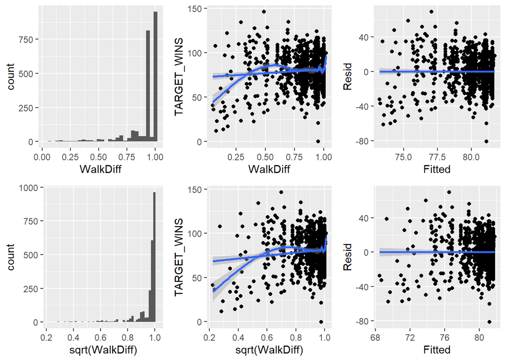

```r
WalkDiff_LM2_DF <- data.frame(WalkDiff_LM2$fitted.values, WalkDiff_LM2$residuals)
names(WalkDiff_LM2_DF) <- c("Fitted","Resid")

p6 <- ggplot(data=WalkDiff_LM2_DF, aes(y=Resid, x = Fitted )) + geom_jitter() + geom_smooth(method='lm', formula= y~x)

grid.arrange(p1, p2, p3, p4, p5, p6, nrow = 2)
```

## TEAM_BATTING_HR

We see that Home Runs is bi-model in nature, likely due to variation in the way the game has evolved. If we were to subset this data by era, we might see several distinct normal distributions. By taking the Log, we find the bi-model distribution becomes more normal, and that the range changes in a manner more fitting for a linear model. Reviewing our residual plots, we find that before the transformation, we have a much higher degree of variation for lower values. This is largely fixed after the transformation.

```r
#Not Transformed
p1 <- ggplot(data=train2, aes(x=TEAM_BATTING_HR)) + geom_histogram()
p2 <- ggplot(data=train2, aes(x = TEAM_BATTING_HR, y=TARGET_WINS)) + geom_jitter() + geom_smooth(formula= y~x) + geom_smooth(method='lm', formula= y~x)
TEAM_BATTING_HR_LM = lm(TARGET_WINS ~ TEAM_BATTING_HR, data = train2)

print(paste("Non Transformed",summary(TEAM_BATTING_HR_LM)$r.squared))
```

```
## [1] "Non Transformed 0.0310299500358932"
```

```r
TEAM_BATTING_HR_LM_DF <- data.frame(TEAM_BATTING_HR_LM$fitted.values, TEAM_BATTING_HR_LM$residuals)
names(TEAM_BATTING_HR_LM_DF) <- c("Fitted","Resid")

p3 <- ggplot(data=TEAM_BATTING_HR_LM_DF, aes(y=Resid, x = Fitted )) + geom_jitter() + geom_smooth(method='lm', formula= y~x)


#Log10

p4 <- ggplot(data=train2, aes(x=log10(TEAM_BATTING_HR+1))) + geom_histogram()
p5 <- ggplot(data=train2, aes(x = log10(TEAM_BATTING_HR+1), y=TARGET_WINS)) + geom_jitter() + geom_smooth(formula= y~x) + geom_smooth(method='lm', formula= y~x)
TEAM_BATTING_HR_LM2 = lm(TARGET_WINS ~ log10(TEAM_BATTING_HR+1), data = train2)

print(paste("Log10",summary(TEAM_BATTING_HR_LM2)$r.squared))
```

```
## [1] "Log10 0.0418750229513914"
```

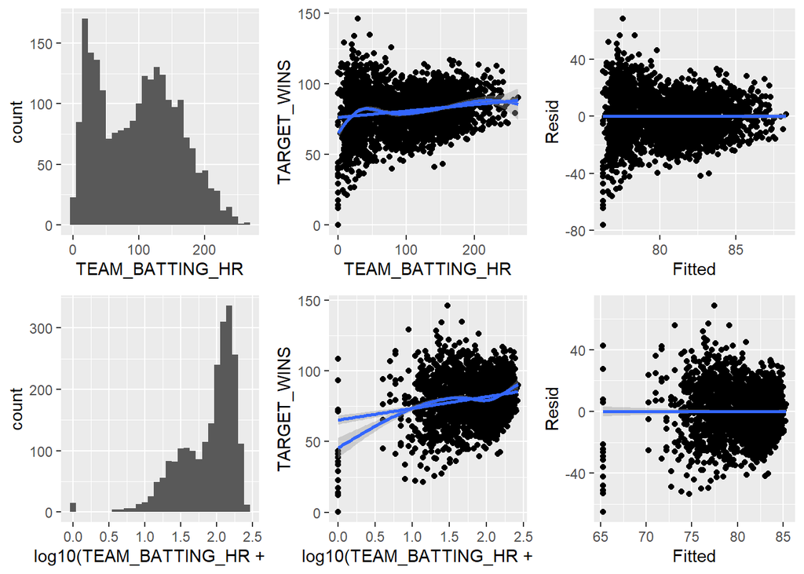

```r
TEAM_BATTING_HR_LM2_DF <- data.frame(TEAM_BATTING_HR_LM2$fitted.values, TEAM_BATTING_HR_LM2$residuals)
names(TEAM_BATTING_HR_LM2_DF) <- c("Fitted","Resid")

p6 <- ggplot(data=TEAM_BATTING_HR_LM2_DF, aes(y=Resid, x = Fitted )) + geom_jitter() + geom_smooth(method='lm', formula= y~x)

grid.arrange(p1, p2, p3, p4, p5, p6, nrow = 2)
```

## TEAM_PITCHING_BB

At first glance, it appears that a log transformation increases the predictive power of the pitching/walks metric.

```r
#Not Transformed
p1 <- ggplot(data=train2, aes(x=TEAM_PITCHING_BB)) + geom_histogram()
p2 <- ggplot(data=train2, aes(x = TEAM_PITCHING_BB, y=TARGET_WINS)) + geom_jitter() + geom_smooth(formula= y~x) + geom_smooth(method='lm', formula= y~x)
TEAM_PITCHING_BB_LM = lm(TARGET_WINS ~ TEAM_PITCHING_BB, data = train2)

print(paste("Non Transformed",summary(TEAM_PITCHING_BB_LM)$r.squared))
```

```
## [1] "Non Transformed 0.015419315390593"
```

```r
TEAM_PITCHING_BB_LM_DF <- data.frame(TEAM_PITCHING_BB_LM$fitted.values, TEAM_PITCHING_BB_LM$residuals)
names(TEAM_PITCHING_BB_LM_DF) <- c("Fitted","Resid")

p3 <- ggplot(data=TEAM_PITCHING_BB_LM_DF, aes(y=Resid, x = Fitted )) + geom_jitter() + geom_smooth(method='lm', formula= y~x)


#Log10

p4 <- ggplot(data=train2, aes(x=log10(TEAM_PITCHING_BB+1))) + geom_histogram()
p5 <- ggplot(data=train2, aes(x = log10(TEAM_PITCHING_BB+1), y=TARGET_WINS)) + geom_jitter() + geom_smooth(formula= y~x) + geom_smooth(method='lm', formula= y~x)
TEAM_PITCHING_BB_LM2 = lm(TARGET_WINS ~ log10(TEAM_PITCHING_BB+1), data = train2)

print(paste("Log10",summary(TEAM_PITCHING_BB_LM2)$r.squared))
```

```
## [1] "Log10 0.0365613920428514"
```

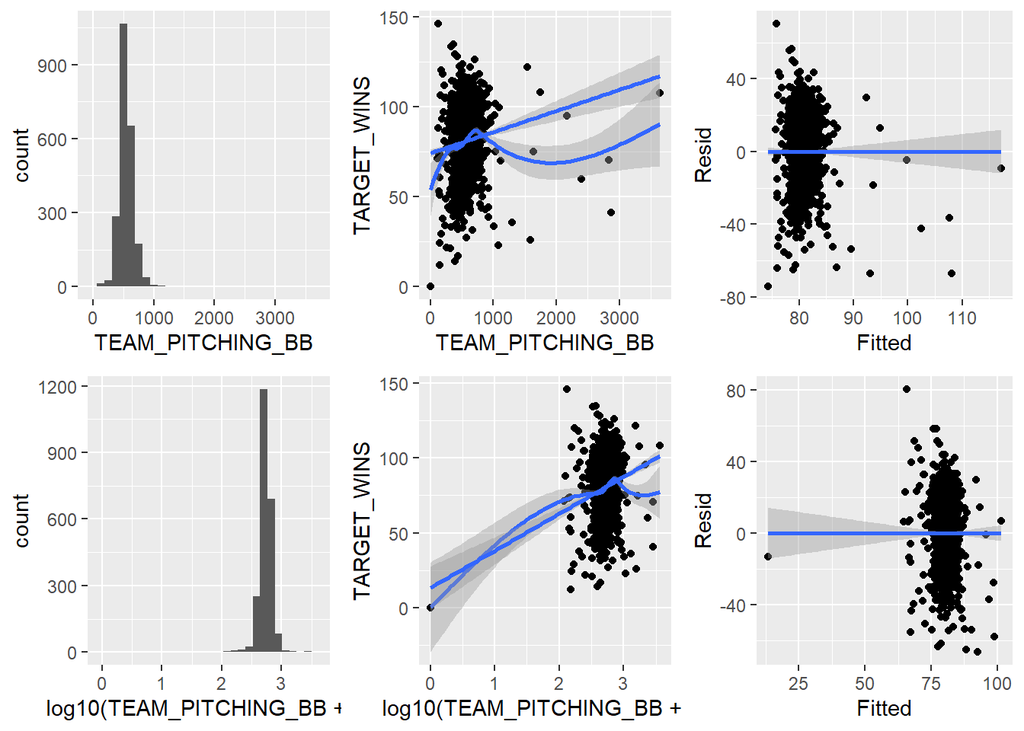

```r
TEAM_PITCHING_BB_LM2_DF <- data.frame(TEAM_PITCHING_BB_LM2$fitted.values, TEAM_PITCHING_BB_LM2$residuals)
names(TEAM_PITCHING_BB_LM2_DF) <- c("Fitted","Resid")

p6 <- ggplot(data=TEAM_PITCHING_BB_LM2_DF, aes(y=Resid, x = Fitted )) + geom_jitter() + geom_smooth(method='lm', formula= y~x)

grid.arrange(p1, p2, p3, p4, p5, p6, nrow = 2)
```

However, after a closer look, we find that this is actually due to the treatment of outliers. Notice the extreme high values before the transformation, and the low value after the transformation.

We can accomplish an increased level of predictiveness by removing these extremes with the median of the set. It is likely that these are in fact errors in the data.

```r
train2 <- train2 %>% mutate(TEAM_PITCHING_BB = ifelse(TEAM_PITCHING_BB > 1300, median(TEAM_PITCHING_BB), TEAM_PITCHING_BB))

train2 <- train2 %>% mutate(TEAM_PITCHING_BB = ifelse(TEAM_PITCHING_BB < 20, median(TEAM_PITCHING_BB), TEAM_PITCHING_BB))

#Not Transformed
p1 <- ggplot(data=train2, aes(x=TEAM_PITCHING_BB)) + geom_histogram()
p2 <- ggplot(data=train2, aes(x = TEAM_PITCHING_BB, y=TARGET_WINS)) + geom_jitter() + geom_smooth(formula= y~x) + geom_smooth(method='lm', formula= y~x)
TEAM_PITCHING_BB_LM = lm(TARGET_WINS ~ TEAM_PITCHING_BB, data = train2)

print(paste("Non Transformed",summary(TEAM_PITCHING_BB_LM)$r.squared))
```

```
## [1] "Non Transformed 0.0300805460927264"
```

```r
TEAM_PITCHING_BB_LM_DF <- data.frame(TEAM_PITCHING_BB_LM$fitted.values, TEAM_PITCHING_BB_LM$residuals)
names(TEAM_PITCHING_BB_LM_DF) <- c("Fitted","Resid")

p3 <- ggplot(data=TEAM_PITCHING_BB_LM_DF, aes(y=Resid, x = Fitted )) + geom_jitter() + geom_smooth(method='lm', formula= y~x)


#Log10

p4 <- ggplot(data=train2, aes(x=log10(TEAM_PITCHING_BB+1))) + geom_histogram()
p5 <- ggplot(data=train2, aes(x = log10(TEAM_PITCHING_BB+1), y=TARGET_WINS)) + geom_jitter() + geom_smooth(formula= y~x) + geom_smooth(method='lm', formula= y~x)
TEAM_PITCHING_BB_LM2 = lm(TARGET_WINS ~ log10(TEAM_PITCHING_BB+1), data = train2)

print(paste("Log10",summary(TEAM_PITCHING_BB_LM2)$r.squared))
```

```
## [1] "Log10 0.0306412506208457"
```

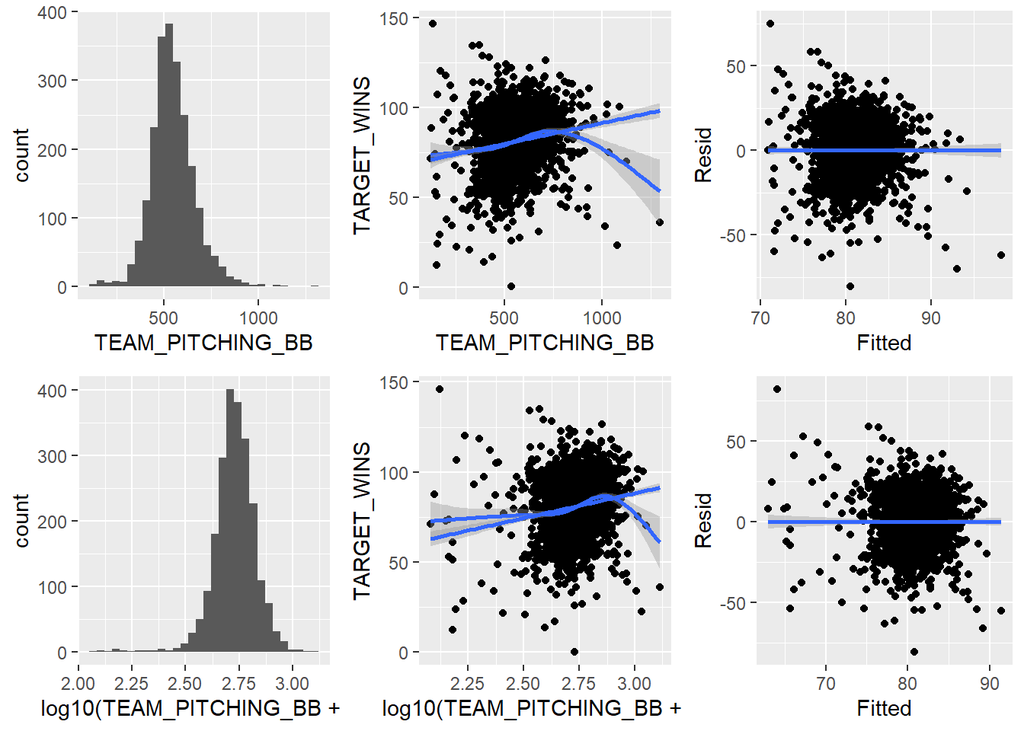

```r
TEAM_PITCHING_BB_LM2_DF <- data.frame(TEAM_PITCHING_BB_LM2$fitted.values, TEAM_PITCHING_BB_LM2$residuals)
names(TEAM_PITCHING_BB_LM2_DF) <- c("Fitted","Resid")

p6 <- ggplot(data=TEAM_PITCHING_BB_LM2_DF, aes(y=Resid, x = Fitted )) + geom_jitter() + geom_smooth(method='lm', formula= y~x)

grid.arrange(p1, p2, p3, p4, p5, p6, nrow = 2)
```

The log transformation does improve our predictive power but only slightly.

# Model 1

Lets begin with a straightforward Linear Model.

```r
model.1a <- lm(TARGET_WINS ~ ., data = train1)
print(paste("R^2 of model with all provided variables no transformations:", summary(model.1a)$r.squared))
```

```
## [1] "R^2 of model with all provided variables no transformations: 0.323661867109824"
```

```r
model.1b <- lm(TARGET_WINS ~ ., data = train2)
print(paste("R^2 of model with all provided variables, calculated variables, truncated but no transformations:", summary(model.1b)$r.squared))
```

```
## [1] "R^2 of model with all provided variables, calculated variables, truncated but no transformations: 0.342745114405795"
```

```r
#summary(model.1b)


model.1c <- lm(TARGET_WINS~TEAM_BATTING_H+TEAM_BATTING_2B+log10(TEAM_BATTING_HR+1)+TEAM_BATTING_BB+TEAM_PITCHING_H+TEAM_PITCHING_HR+log10(TEAM_PITCHING_BB+1)+TEAM_FIELDING_E + TEAM_BASERUN_SB + TEAM_PITCHING_SO + TEAM_FIELDING_DP + SLG1 + SLG2 + HRDiff  + WalkDiff, data = train2)

print(paste("R^2 simplest, most predictive model of this type:", summary(model.1c)$r.squared))
```

```
## [1] "R^2 simplest, most predictive model of this type: 0.343309691601957"
```

```r
summary(model.1c)
```

```
##
## Call:
## lm(formula = TARGET_WINS ~ TEAM_BATTING_H + TEAM_BATTING_2B +
##     log10(TEAM_BATTING_HR + 1) + TEAM_BATTING_BB + TEAM_PITCHING_H +
##     TEAM_PITCHING_HR + log10(TEAM_PITCHING_BB + 1) + TEAM_FIELDING_E +
##     TEAM_BASERUN_SB + TEAM_PITCHING_SO + TEAM_FIELDING_DP + SLG1 +
##     SLG2 + HRDiff + WalkDiff, data = train2)
##
## Residuals:
##     Min      1Q  Median      3Q     Max
## -49.407  -8.200   0.274   8.142  64.091
##
## Coefficients:
##                               Estimate Std. Error t value Pr(>|t|)
## (Intercept)                  -1.997636  43.458645  -0.046 0.963341
## TEAM_BATTING_H                0.074946   0.025975   2.885 0.003947 **
## TEAM_BATTING_2B              -0.064332   0.011170  -5.759 9.59e-09 ***
## log10(TEAM_BATTING_HR + 1)   -6.218385   2.636250  -2.359 0.018419 *
## TEAM_BATTING_BB               0.042465   0.006956   6.105 1.21e-09 ***
## TEAM_PITCHING_H               0.002745   0.001021   2.689 0.007228 **
## TEAM_PITCHING_HR             -0.070582   0.021203  -3.329 0.000886 ***
## log10(TEAM_PITCHING_BB + 1) -28.092780   6.635029  -4.234 2.39e-05 ***
## TEAM_FIELDING_E              -0.037490   0.002950 -12.710  < 2e-16 ***
## TEAM_BASERUN_SB               0.030108   0.003976   7.572 5.32e-14 ***
## TEAM_PITCHING_SO             -0.003666   0.001877  -1.953 0.050886 .
## TEAM_FIELDING_DP             -0.100609   0.013243  -7.597 4.41e-14 ***
## SLG1                         99.217346  27.704081   3.581 0.000349 ***
## SLG2                         -0.011744   0.019529  -0.601 0.547637
## HRDiff                      -15.053474   5.830748  -2.582 0.009893 **
## WalkDiff                    -25.190016   7.897777  -3.190 0.001445 **
## ---
## Signif. codes:  0 '***' 0.001 '**' 0.01 '*' 0.05 '.' 0.1 ' ' 1
##
## Residual standard error: 12.81 on 2260 degrees of freedom
## Multiple R-squared:  0.3433, Adjusted R-squared:  0.339
## F-statistic: 78.77 on 15 and 2260 DF,  p-value: < 2.2e-16
```